# Pilot study: LLM support and unaided performance — Supplementary analyses

2026-10-30

```r
knitr::opts_chunk$set(
  echo = TRUE, message = FALSE, warning = FALSE,
  fig.width = 8, fig.height = 5, dpi = 120
)
library(dplyr)
library(tidyr)
library(ggplot2)
library(emmeans)
condition_levels <- c(
  "Control_Group", "Control_Group_Bonus",
  "AI_Group_Flat", "AI_Group_Bonus"
)
condition_labels <- c(
  Control_Group = "Control (no incentive)",
  Control_Group_Bonus = "Control + incentive",
  AI_Group_Flat = "LLM (no incentive)",
  AI_Group_Bonus = "LLM + incentive"
)
figure_font <- "sans"
theme_set(
  theme_minimal(base_size = 12, base_family = figure_font) +
    theme(legend.position = "bottom", panel.grid.minor = element_blank())
)

# Knitting uses the directory containing this R Markdown file.
figure_dir <- file.path("output", "figures")
dir.create(figure_dir, recursive = TRUE, showWarnings = FALSE)

fmt_p <- function(p) {
  ifelse(is.na(p), NA_character_,
         ifelse(p < .001, "< .001", sprintf("%.3f", p)))
}
```

# 1 Data preparation

The analysis uses participant scores and LLM request logs.

```r
read_public <- function(name) read.csv(
  file.path("data", name), na.strings = c("", "NA"),
  check.names = FALSE, stringsAsFactors = FALSE
)
participants_all <- read_public("participants_public.csv")
ai_consultations <- read_public("ai_consultations_public.csv")
score_rounds <- c("bl", "t1", "t2", "test", "del")
participants_all <- participants_all %>%
  mutate(attention_check_passed = as.logical(attention_check_passed))
# Unique participant IDs prevent joins from duplicating observations.
stopifnot(!anyDuplicated(participants_all$participant_id))
```

```r
score_proportion <- function(correct, total) {
  ifelse(!is.na(total) & total > 0, correct / total, NA_real_)
}
for (phase in score_rounds) {
  correct <- participants_all[[paste0(phase, "_score_correct")]]
  total <- participants_all[[paste0(phase, "_score_total")]]
  stopifnot(all(total >= 0, na.rm = TRUE),
            all(correct >= 0 & correct <= total, na.rm = TRUE))
  participants_all[[paste0(phase, "_score_proportion")]] <- score_proportion(correct, total)
}
participants_all <- participants_all %>%
  mutate(
    consent_withdrawn = status == "withdrawn",
    assigned = group_condition %in% condition_levels,
    has_baseline = !is.na(bl_score_proportion),
    has_training_1 = !is.na(t1_score_proportion),
    has_training_2 = !is.na(t2_score_proportion),
    has_immediate_test = !is.na(test_score_proportion),
    has_delayed_test = !is.na(del_score_proportion),
    attention_check_missing = is.na(attention_check_passed),
    attention_check_passed = coalesce(attention_check_passed, FALSE),
    declined_data_use = coalesce(use_data_for_study == "no", FALSE),
    ai = ifelse(assigned, as.integer(group_condition %in%
                  c("AI_Group_Flat", "AI_Group_Bonus")), NA_integer_),
    incentive = ifelse(assigned, as.integer(group_condition %in%
                         c("Control_Group_Bonus", "AI_Group_Bonus")), NA_integer_),
    condition_label = factor(unname(condition_labels[group_condition]),
                             levels = unname(condition_labels[condition_levels])),
    predicted_proportion = score_proportion(test_predicted_correct, test_prediction_n_items),
    metacognitive_bias = predicted_proportion - test_score_proportion,
    included_retention = assigned & !consent_withdrawn & !declined_data_use & has_baseline
  )
sample_steps <- list(
  "Approved on Prolific" = participants_all$recruitment_status == "APPROVED",
  "Consent not withdrawn" = !participants_all$consent_withdrawn,
  "Continued after baseline" = participants_all$assigned,
  "Reached immediate unaided test" = participants_all$has_immediate_test,
  "Passed the attention check" = participants_all$attention_check_passed,
  "Honesty check approved" = !participants_all$declined_data_use
)
sample_kept <- Reduce(`&`, sample_steps, accumulate = TRUE)
participants_all <- participants_all %>%
  mutate(
    included_primary = sample_kept[[length(sample_kept)]],
    exclusion_reason = case_when(
      consent_withdrawn ~ "Consent withdrawn",
      !assigned ~ "Dropped out after baseline",
      !has_immediate_test ~ "No immediate test",
      !attention_check_passed ~ "Attention check not passed",
      declined_data_use ~ "Excluded: honesty check not approved",
      TRUE ~ "Included"
    )
  )
participants <- participants_all %>%
  filter(included_primary) %>%
  mutate(baseline_c = bl_score_proportion - mean(bl_score_proportion))
```

## 1.1 Primary-sample age

Age statistics are calculated from `primary_sample_age_aggregates.csv`; individual ages are omitted from the public data.

```r
age_aggregates <- read_public("primary_sample_age_aggregates.csv")
# The anonymised age aggregates must describe the analysed sample.
stopifnot(age_aggregates$n_participants == nrow(participants))
age_summary <- age_aggregates %>%
  transmute(
    N = n_participants,
    N_age = n_age,
    N_missing_age = n_participants - n_age,
    Mean_age = sum_age / n_age,
    SD_age = sqrt((sum_squared_age - sum_age^2 / n_age) / (n_age - 1)),
    Min_age = min_age,
    Max_age = max_age
  )
knitr::kable(age_summary, digits = c(0, 0, 0, 1, 1, 0, 0))
```

| N | N_age | N_missing_age | Mean_age | SD_age | Min_age | Max_age |
| --- | --- | --- | --- | --- | --- | --- |
| 408 | 408 | 0 | 39.3 | 12.1 | 18 | 73 |

```r
cat(sprintf(
  "The mean age of participants in the primary sample was %.1f years (SD = %.1f, range = %d–%d).\n",
  age_summary$Mean_age, age_summary$SD_age,
  age_summary$Min_age, age_summary$Max_age
))
```

```
## The mean age of participants in the primary sample was 39.3 years (SD = 12.1, range = 18–73).
```

LLM use is defined as at least one request, counted across the 14 training items and separately for each item.

```r
request_counts <- ai_consultations %>%
  count(participant_id, training_session, item_position, name = "prompt_count") %>%
  rename(position = item_position)
ai_training_items <- tidyr::crossing(
  participant_id = participants$participant_id[participants$ai == 1],
  training_session = 1:2, position = 1:7
) %>%
  left_join(request_counts, by = c("participant_id", "training_session", "position")) %>%
  mutate(prompt_count = coalesce(prompt_count, 0L), any_use = prompt_count > 0) %>%
  left_join(participants %>% select(participant_id, incentive), by = "participant_id")
participant_consultation <- ai_training_items %>%
  group_by(participant_id) %>%
  summarise(used_ai_training = any(any_use),
            ai_consulted_items_percent = 100 * mean(any_use), .groups = "drop")
participants <- participants %>% left_join(participant_consultation, by = "participant_id")
ai_item_consultation <- ai_training_items %>%
  group_by(incentive, training_session, position) %>%
  summarise(n = n(), consulted = sum(any_use), percent = 100 * mean(any_use),
            .groups = "drop") %>%
  mutate(
    condition = factor(incentive, levels = c(0, 1), labels = c("No incentive", "Incentive")),
    session = factor(training_session, levels = c(1, 2),
                     labels = c("Practice session 1", "Practice session 2")),
    item_position = factor(position, levels = 1:7)
  )
recorded_training_counts <- participants %>% filter(ai == 1) %>%
  select(participant_id, t1_ai_requests_count, t2_ai_requests_count) %>%
  pivot_longer(c(t1_ai_requests_count, t2_ai_requests_count),
               names_to = "training_session", values_to = "recorded_requests") %>%
  mutate(training_session = ifelse(training_session == "t1_ai_requests_count", 1L, 2L)) %>%
  left_join(ai_training_items %>% group_by(participant_id, training_session) %>%
    summarise(observed_requests = sum(prompt_count), .groups = "drop"),
    by = c("participant_id", "training_session"))
# Reconcile request logs with participant-level totals before analysing LLM use.
stopifnot(all(
  recorded_training_counts$recorded_requests == recorded_training_counts$observed_requests
))
```

# 2 Results from pilot data

Condition means, standard deviations, and assessment sample sizes correspond to Supplementary Table 7.

```r
condition_outcomes <- participants %>%
  group_by(condition_label, .drop = FALSE) %>%
  summarise(
    N_T1 = n(), N_T2 = sum(has_delayed_test),
    across(c(bl_score_proportion, metacognitive_bias,
             test_score_proportion, del_score_proportion),
      ~ sprintf("%.2f (%.2f)", mean(.x, na.rm = TRUE), sd(.x, na.rm = TRUE))),
    .groups = "drop"
  )
knitr::kable(condition_outcomes)
```

| condition_label | N_T1 | N_T2 | bl_score_proportion | metacognitive_bias | test_score_proportion | del_score_proportion |
| --- | --- | --- | --- | --- | --- | --- |
| Control (no incentive) | 100 | 86 | 0.44 (0.26) | -0.02 (0.24) | 0.65 (0.27) | 0.61 (0.27) |
| Control + incentive | 102 | 89 | 0.44 (0.29) | -0.03 (0.25) | 0.63 (0.32) | 0.60 (0.28) |
| LLM (no incentive) | 100 | 84 | 0.47 (0.27) | -0.02 (0.21) | 0.59 (0.29) | 0.60 (0.29) |
| LLM + incentive | 106 | 95 | 0.45 (0.28) | 0.01 (0.27) | 0.63 (0.30) | 0.62 (0.29) |

**Full output and unformatted results**

```r
condition_outcomes_raw <- participants %>%
  group_by(condition_label, .drop = FALSE) %>%
  summarise(
    N_T1 = n(), N_T2 = sum(has_delayed_test),
    across(c(bl_score_proportion, metacognitive_bias,
             test_score_proportion, del_score_proportion),
      list(mean = ~ mean(.x, na.rm = TRUE), sd = ~ sd(.x, na.rm = TRUE))),
    .groups = "drop"
  )
print(as.data.frame(condition_outcomes_raw), digits = 17, row.names = FALSE)
```

```
##         condition_label N_T1 N_T2 bl_score_proportion_mean
##  Control (no incentive)  100   86      0.43900000000000000
##     Control + incentive  102   89      0.44215686274509802
##      LLM (no incentive)  100   84      0.47499999999999998
##         LLM + incentive  106   95      0.44528301886792454
##  bl_score_proportion_sd metacognitive_bias_mean metacognitive_bias_sd
##     0.26242651689125612   -0.016999999999999998   0.23572582944316198
##     0.28819557252279793   -0.025490196078431365   0.24522621381600987
##     0.27168572158494331   -0.016000000000000000   0.21116320463068131
##     0.27676088199767862    0.014150943396226415   0.27340487306949962
##  test_score_proportion_mean test_score_proportion_sd del_score_proportion_mean
##         0.64500000000000002      0.27205725778804640       0.60813953488372097
##         0.62745098039215685      0.31939201610172463       0.60112359550561800
##         0.58999999999999997      0.29249881291307089       0.60357142857142854
##         0.63207547169811318      0.30380042628620557       0.61894736842105269
##  del_score_proportion_sd
##      0.26710434897645163
##      0.27530742404152486
##      0.28725809249516143
##      0.29183744267165035
```

The performance model (Equation 1) tests H1–H6; the metacognitive-bias model (Equation 2) tests H7. The performance and learning-trajectory mixed models use restricted maximum likelihood (REML) and Satterthwaite degrees of freedom for contrasts and confidence intervals.

```r
design_equivalence_d <- c(H1 = .20, H2 = .20, H3 = .20, H4 = .20,
                          H5 = .10, H6 = .10, H7 = .10)

pooled_cell_standardizer <- function(outcome, group) {
  keep <- complete.cases(outcome, group)
  cells <- split(outcome[keep], factor(group[keep]))
  cell_n <- vapply(cells, length, integer(1))
  if (any(cell_n < 2L)) {
    stop("Equivalence standardization requires at least two observations per cell.")
  }
  list(
    sd = sqrt(sum((cell_n - 1) * vapply(cells, var, numeric(1))) / sum(cell_n - 1)),
    df = sum(cell_n - 1)
  )
}

summarize_design_contrast <- function(grid, weights, hypothesis, outcome,
                                      direction, standardizer) {
  bound <- design_equivalence_d[[hypothesis]] * standardizer$sd
  comparison <- contrast(
    grid, method = setNames(list(weights), hypothesis), adjust = "none"
  )
  result <- as.data.frame(confint(comparison, level = .90, adjust = "none"))
  standardized <- as.data.frame(summary(
    emmeans::eff_size(comparison, sigma = standardizer$sd,
                      edf = standardizer$df, method = "identity"),
    infer = c(FALSE, FALSE)
  ))
  p_directional <- emmeans::test(
    comparison, side = if (direction == "negative") "<" else ">", adjust = "none"
  )$p.value
  p_equivalence <- emmeans::test(
    comparison, delta = bound, side = "two-sided", adjust = "none"
  )$p.value
  data.frame(
    Hypothesis = hypothesis, Outcome = outcome,
    Contrast = dplyr::case_when(
      hypothesis %in% c("H1", "H2", "H7") ~ "LLM − control, no incentive",
      hypothesis %in% c("H3", "H4") ~ "Incentive − no incentive, LLM",
      TRUE ~ "LLM × incentive"
    ),
    estimate = result$estimate, SE = result$SE, df = result$df,
    CI_low = result$lower.CL, CI_high = result$upper.CL,
    standardizing_sd = standardizer$sd, standardizing_df = standardizer$df,
    cohens_d = standardized$effect.size, equivalence_bound = bound,
    p_one_sided = p_directional, p_equivalence = p_equivalence,
    Interpretation = dplyr::case_when(
      p_directional < .05 & p_equivalence < .05 ~
        "Evidence in predicted direction; equivalent within bounds",
      p_directional < .05 ~ "Evidence in predicted direction",
      p_equivalence < .05 ~ "Equivalent within bounds",
      TRUE ~ "Inconclusive"
    )
  )
}

fit_design_table <- function(dat) {
  long <- dat %>%
    select(participant_id, ai, incentive, baseline_c,
           Immediate = test_score_proportion, Delayed = del_score_proportion) %>%
    pivot_longer(c(Immediate, Delayed), names_to = "time", values_to = "performance") %>%
    filter(complete.cases(performance, baseline_c)) %>%
    mutate(time = factor(time, levels = c("Immediate", "Delayed")))
  performance_model <- lme4::lmer(
    performance ~ time * (ai * incentive + baseline_c) + (1 | participant_id),
    data = long, REML = TRUE
  )
  performance_grid <- emmeans(
    performance_model, ~ ai * incentive | time,
    at = list(ai = c(0, 1), incentive = c(0, 1), baseline_c = 0),
    lmer.df = "satterthwaite"
  )
  # Explicit grid order: control/no incentive, LLM/no incentive,
  # control/incentive, LLM/incentive.
  stopifnot(
    identical(as.numeric(performance_grid@grid$ai), rep(c(0, 1, 0, 1), 2)),
    identical(as.numeric(performance_grid@grid$incentive), rep(c(0, 0, 1, 1), 2))
  )
  results <- bind_rows(lapply(c("Immediate", "Delayed"), function(assessment) {
    grid <- performance_grid[performance_grid@grid$time == assessment, ]
    observed <- long %>% filter(time == assessment)
    no_inc <- observed %>% filter(incentive == 0)
    ai_only <- observed %>% filter(ai == 1)
    numbers <- if (assessment == "Immediate") c("H1", "H3", "H5") else c("H2", "H4", "H6")
    no_inc_scale <-
      pooled_cell_standardizer(no_inc$performance, no_inc$ai)
    ai_only_scale <-
      pooled_cell_standardizer(ai_only$performance, ai_only$incentive)
    interaction_scale <- pooled_cell_standardizer(
      observed$performance, interaction(observed$ai, observed$incentive))
    bind_rows(
      summarize_design_contrast(grid, c(-1, 1, 0, 0), numbers[1], assessment,
        "negative", no_inc_scale),
      summarize_design_contrast(grid, c(0, -1, 0, 1), numbers[2], assessment,
        "positive", ai_only_scale),
      summarize_design_contrast(grid, c(1, -1, -1, 1), numbers[3], assessment,
        "positive", interaction_scale)
    )
  }))
  # Equation 2 specifies H7 without baseline adjustment.
  bias_model <- lm(metacognitive_bias ~ ai * incentive, data = dat)
  bias_grid <- emmeans(bias_model, ~ ai * incentive,
    at = list(ai = c(0, 1), incentive = c(0, 1)))
  no_inc <- dat %>% filter(incentive == 0)
  bias_scale <-
    pooled_cell_standardizer(no_inc$metacognitive_bias, no_inc$ai)
  results <- bind_rows(results,
    summarize_design_contrast(bias_grid, c(-1, 1, 0, 0), "H7", "Immediate bias",
      "positive", bias_scale)) %>%
    arrange(Hypothesis)
  list(performance_model = performance_model, bias_model = bias_model,
       performance_grid = performance_grid, long = long, results = results)
}

format_design_results <- function(results) {
  results %>% transmute(
    Hypothesis, Outcome, Contrast,
    `Effect (pp)` = sprintf("%.2f", 100 * estimate),
    `90% CI (pp)` = sprintf("[%.2f, %.2f]", 100 * CI_low, 100 * CI_high),
    `Cohen's d` = sprintf("%.2f", cohens_d),
    `One-sided p` = fmt_p(p_one_sided),
    `Equivalence bounds (d)` = sprintf("±%.2f", equivalence_bound / standardizing_sd),
    `Equivalence p` = fmt_p(p_equivalence),
    Interpretation
  )
}

design_table <- fit_design_table(participants)
```

```r
knitr::kable(coef(summary(design_table$performance_model)),
             digits = 3, caption = "Performance model: fixed effects")
```

Performance model: fixed effects

|  | Estimate | Std. Error | t value |
| --- | --- | --- | --- |
| (Intercept) | 0.653 | 0.022 | 30.333 |
| timeDelayed | -0.023 | 0.018 | -1.254 |
| ai | -0.081 | 0.030 | -2.669 |
| incentive | -0.020 | 0.030 | -0.655 |
| baseline_c | 0.732 | 0.039 | 18.793 |
| ai:incentive | 0.084 | 0.043 | 1.961 |
| timeDelayed:ai | 0.041 | 0.026 | 1.560 |
| timeDelayed:incentive | 0.004 | 0.026 | 0.143 |
| timeDelayed:baseline_c | -0.049 | 0.033 | -1.459 |
| timeDelayed:ai:incentive | -0.034 | 0.036 | -0.929 |

```r
knitr::kable(as.data.frame(lme4::VarCorr(design_table$performance_model)),
             digits = 3, caption = "Performance model: variance components")
```

Performance model: variance components

| grp | var1 | var2 | vcov | sdcor |
| --- | --- | --- | --- | --- |
| participant_id | (Intercept) | NA | 0.031 | 0.177 |
| Residual | NA | NA | 0.015 | 0.122 |

```r
knitr::kable(coef(summary(design_table$bias_model)),
             digits = 3, caption = "Metacognitive-bias model: coefficients")
```

Metacognitive-bias model: coefficients

|  | Estimate | Std. Error | t value | Pr(>\|t\|) |
| --- | --- | --- | --- | --- |
| (Intercept) | -0.017 | 0.024 | -0.700 | 0.484 |
| ai | 0.001 | 0.034 | 0.029 | 0.977 |
| incentive | -0.008 | 0.034 | -0.248 | 0.804 |
| ai:incentive | 0.039 | 0.048 | 0.803 | 0.422 |

```r
bias_summary <- summary(design_table$bias_model)
knitr::kable(data.frame(
  N = nobs(design_table$bias_model),
  Residual_SE = bias_summary$sigma,
  Residual_df = df.residual(design_table$bias_model),
  R_squared = bias_summary$r.squared,
  Adjusted_R_squared = bias_summary$adj.r.squared,
  F = unname(bias_summary$fstatistic["value"]),
  Numerator_df = unname(bias_summary$fstatistic["numdf"]),
  Denominator_df = unname(bias_summary$fstatistic["dendf"])
), digits = 3, caption = "Metacognitive-bias model: fit statistics")
```

Metacognitive-bias model: fit statistics

| N | Residual_SE | Residual_df | R_squared | Adjusted_R_squared | F | Numerator_df | Denominator_df |
| --- | --- | --- | --- | --- | --- | --- | --- |
| 408 | 0.243 | 404 | 0.004 | -0.003 | 0.534 | 3 | 404 |

**Full output and unformatted results**

```r
print(summary(design_table$performance_model), correlation = TRUE, digits = 17)
```

```
## Linear mixed model fit by REML ['lmerMod']
## Formula:
## performance ~ time * (ai * incentive + baseline_c) + (1 | participant_id)
##    Data: long
##
## REML criterion at convergence: -348
##
## Scaled residuals:
##                     Min                      1Q                  Median
## -2.48211771941659575802 -0.46144528911958282436 -0.00092767701670457199
##                      3Q                     Max
##  0.47869261362051906961  2.25124580940535690132
##
## Random effects:
##  Groups         Name        Variance             Std.Dev.
##  participant_id (Intercept) 0.031465613750097911 0.17738549475675261
##  Residual                   0.014892614919956302 0.12203530194151323
## Number of obs: 762, groups:  participant_id, 408
##
## Fixed effects:
##                                        Estimate             Std. Error
## (Intercept)               0.6532313915524913250  0.0215354157072822489
## timeDelayed              -0.0230918139961201092  0.0184177999576977322
## ai                       -0.0813519352926447836  0.0304816462587630191
## incentive                -0.0198598374630445142  0.0302999974242992749
## baseline_c                0.7319982025727246322  0.0389502020951849950
## ai:incentive              0.0836880859357168050  0.0426689386459696285
## timeDelayed:ai            0.0408609552249235841  0.0261964632892395417
## timeDelayed:incentive     0.0036851558699113104  0.0258145227124053842
## timeDelayed:baseline_c   -0.0488689384502225405  0.0334976375361418152
## timeDelayed:ai:incentive -0.0337697036575706974  0.0363478545248825599
##                                       t value
## (Intercept)              30.33288999999999902
## timeDelayed              -1.25377999999999989
## ai                       -2.66888000000000014
## incentive                -0.65544000000000002
## baseline_c               18.79317999999999955
## ai:incentive              1.96134000000000008
## timeDelayed:ai            1.55979000000000001
## timeDelayed:incentive     0.14276000000000000
## timeDelayed:baseline_c   -1.45887999999999995
## timeDelayed:ai:incentive -0.92906999999999995
##
## Correlation of Fixed Effects:
##             (Intr) tmDlyd ai     incntv bsln_c a:ncnt timDlyd: tmDlyd:n tmDl:_
## timeDelayed -0.376
## ai          -0.707  0.266
## incentive   -0.711  0.267  0.502
## baseline_c   0.020 -0.008 -0.046 -0.004
## ai:incentiv  0.505 -0.190 -0.714 -0.710  0.030
## timeDelayd:  0.264 -0.704 -0.374 -0.188  0.017  0.267
## tmDlyd:ncnt  0.268 -0.712 -0.189 -0.377  0.002  0.268  0.501
## tmDlyd:bsl_ -0.008  0.043  0.017  0.002 -0.374 -0.011 -0.057   -0.006
## tmDlyd::ncn -0.190  0.507  0.269  0.268 -0.011 -0.377 -0.720   -0.710    0.028
```

```r
print(summary(design_table$bias_model), correlation = TRUE, digits = 17)
```

```
##
## Call:
## lm(formula = metacognitive_bias ~ ai * incentive, data = dat)
##
## Residuals:
##                   Min                    1Q                Median
## -0.674509803921568674 -0.174509803921568729 -0.014150943396226436
##                    3Q                   Max
##  0.117000000000000229  0.985849056603773422
##
## Coefficients:
##                            Estimate             Std. Error              t value
## (Intercept)  -0.0170000000000001053  0.0242909341536503114 -0.69984999999999997
## ai            0.0010000000000001381  0.0343525685228041472  0.02911000000000000
## incentive    -0.0084901960784312062  0.0341837588106772214 -0.24837000000000001
## ai:incentive  0.0386411394746575543  0.0481168297298799202  0.80306999999999995
##              Pr(>|t|)
## (Intercept)   0.48442
## ai            0.97679
## incentive     0.80397
## ai:incentive  0.42241
##
## Residual standard error: 0.2429093 on 404 degrees of freedom
## Multiple R-squared:  0.0039506842513365543,  Adjusted R-squared:  -0.003445721558678283
## F-statistic: 0.53413568060141814 on 3 and 404 DF,  p-value: 0.65911455616956449
```

The H1–H7 contrasts and two-sided 90% confidence intervals are expressed in percentage points. Cohen’s d uses the applicable pooled within-cell SD. The table also reports one-sided directional tests and equivalence tests with bounds of ±0.20 within-cell SD units for H1–H4 and ±0.10 for H5–H7.

```r
knitr::kable(format_design_results(design_table$results))
```

| Hypothesis | Outcome | Contrast | Effect (pp) | 90% CI (pp) | Cohen’s d | One-sided p | Equivalence bounds (d) | Equivalence p | Interpretation |
| --- | --- | --- | --- | --- | --- | --- | --- | --- | --- |
| H1 | Immediate | LLM − control, no incentive | -8.14 | [-13.16, -3.11] | -0.29 | 0.004 | ±0.20 | 0.792 | Evidence in predicted direction |
| H2 | Delayed | LLM − control, no incentive | -4.05 | [-9.31, 1.21] | -0.15 | 0.103 | ±0.20 | 0.320 | Inconclusive |
| H3 | Immediate | Incentive − no incentive, LLM | 6.38 | [1.43, 11.33] | 0.21 | 0.017 | ±0.20 | 0.555 | Evidence in predicted direction |
| H4 | Delayed | Incentive − no incentive, LLM | 3.37 | [-1.78, 8.52] | 0.12 | 0.140 | ±0.20 | 0.220 | Inconclusive |
| H5 | Immediate | LLM × incentive | 8.37 | [1.34, 15.40] | 0.28 | 0.025 | ±0.10 | 0.897 | Evidence in predicted direction |
| H6 | Delayed | LLM × incentive | 4.99 | [-2.32, 12.31] | 0.18 | 0.131 | ±0.10 | 0.688 | Inconclusive |
| H7 | Immediate bias | LLM − control, no incentive | 0.10 | [-5.56, 5.76] | 0.00 | 0.488 | ±0.10 | 0.267 | Inconclusive |

**Full output and unformatted results**

```r
print(as.data.frame(design_table$results), digits = 17, row.names = FALSE)
```

```
##  Hypothesis        Outcome                      Contrast               estimate
##          H1      Immediate   LLM − control, no incentive -0.0813519352926447836
##          H2        Delayed   LLM − control, no incentive -0.0404909800677211995
##          H3      Immediate Incentive − no incentive, LLM  0.0638282484726722943
##          H4        Delayed Incentive − no incentive, LLM  0.0337437006850129020
##          H5      Immediate               LLM × incentive  0.0836880859357168050
##          H6        Delayed               LLM × incentive  0.0499183822781461076
##          H7 Immediate bias   LLM − control, no incentive  0.0010000000000001381
##                    SE                 df                CI_low
##  0.030481646258763019 531.20834656021111 -0.131577371796629317
##  0.031912655386400188 590.52810162229207 -0.093065102963075561
##  0.030037706839255628 531.20834786214937  0.014334303009009570
##  0.031258188070247696 583.03168790586983 -0.017753268208714222
##  0.042668938645969628 531.20834721305198  0.013381316725872755
##  0.044407680218582268 583.17318417076081 -0.023241969776499068
##  0.034352568522804147 404.00000000000000 -0.055634814139271120
##                CI_high    standardizing_sd standardizing_df
##  -0.031126498788660258 0.28246301268547280              198
##   0.012083142827633161 0.27724442217123024              168
##   0.113322193936335025 0.29836928852421002              204
##   0.085240669578740019 0.28969907734398920              177
##   0.153994855145560855 0.29764579858228157              404
##   0.123078734332791290 0.28075924243431427              350
##   0.057634814139271399 0.22378177501370131              198
##              cohens_d    equivalence_bound           p_one_sided
##  -0.28800916098431445 0.056492602537094566 0.0039215556051350109
##  -0.14604795202232554 0.055448884434246053 0.1025050160416959982
##   0.21392365410119346 0.059673857704842008 0.0170264150400957007
##   0.11647845410617436 0.057939815468797840 0.1404021648243962417
##   0.28116669657133414 0.029764579858228158 0.0251809372789756868
##   0.17779782366318672 0.028075924243431430 0.1307179363241646186
##   0.00446863914605607 0.022378177501370132 0.4883956553005791568
##        p_equivalence                  Interpretation
##  0.79243870848775355 Evidence in predicted direction
##  0.31972357105963101                    Inconclusive
##  0.55497444557457243 Evidence in predicted direction
##  0.21960073788864481                    Inconclusive
##  0.89656563393870137 Evidence in predicted direction
##  0.68849906603379751                    Inconclusive
##  0.26704235029771395                    Inconclusive
```

## 2.1 Performance results figure

Figure 3 shows observed baseline means and baseline-adjusted immediate and delayed performance by condition, with 90% confidence intervals.

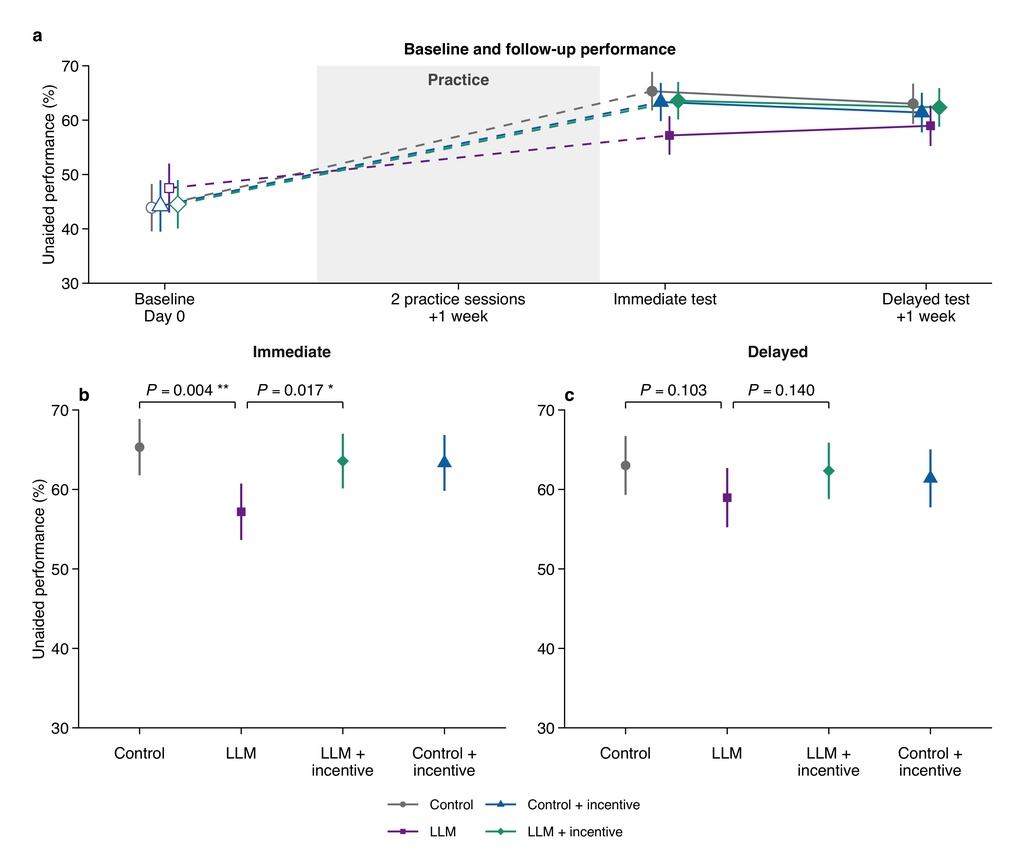

```r
results_conditions <- tibble::tibble(
  condition = condition_levels,
  ai = c(0, 0, 1, 1), incentive = c(0, 1, 0, 1),
  label = c("Control", "Control + incentive", "LLM", "LLM + incentive"),
  colour = c("#808080", "#0072B2", "#7B3294", "#159E7C"),
  shape = c(16, 17, 15, 18), open_shape = c(21, 24, 22, 23),
  size = c(2, 2.3, 1.8, 2.5), panel_x = c(1, 4, 2, 3),
  offset = c(-.06, -.02, .02, .06)
)
results_colours <- setNames(results_conditions$colour, results_conditions$condition)
results_shapes <- setNames(results_conditions$shape, results_conditions$condition)
results_open_shapes <- setNames(results_conditions$open_shape, results_conditions$condition)
results_sizes <- setNames(results_conditions$size, results_conditions$condition)
results_labels <- setNames(results_conditions$label, results_conditions$condition)
results_offsets <- setNames(results_conditions$offset, results_conditions$condition)
results_font <- "Helvetica"
results_ci_level <- .90
results_y_limits <- c(30, 70)
results_time_x <- c(Baseline = 1, Immediate = 3.3, Delayed = 4.5)
results_practice_x <- c(1.7, 3)
results_bracket_y <- 71
results_dimensions <- c(width = 160, height = 135)
results_theme <- theme_classic(base_size = 7, base_family = results_font) +
  theme(
    axis.text = element_text(size = 7, colour = "black"),
    axis.title = element_text(size = 7),
    axis.line = element_line(linewidth = .25),
    axis.ticks = element_line(linewidth = .25),
    axis.ticks.length = grid::unit(1, "mm"),
    plot.margin = margin(2, 3, 1, 3, unit = "mm")
  )

results_cells <- as.data.frame(confint(
  design_table$performance_grid, level = results_ci_level, adjust = "none"
)) %>%
  left_join(results_conditions, by = c("ai", "incentive")) %>%
  transmute(ai, incentive, group = factor(condition, levels = condition_levels),
            assessment = factor(time, levels = c("Immediate", "Delayed")),
            centre = emmean, lower = lower.CL, upper = upper.CL, x = panel_x)
results_baseline_cells <- participants %>%
  transmute(group = factor(group_condition, levels = condition_levels),
            score = bl_score_proportion) %>%
  filter(!is.na(score)) %>%
  group_by(group) %>%
  summarise(n = n(), centre = mean(score), spread = sd(score), .groups = "drop") %>%
  mutate(
    assessment = "Baseline",
    lower = centre - qt((1 + results_ci_level) / 2, n - 1) * spread / sqrt(n),
    upper = centre + qt((1 + results_ci_level) / 2, n - 1) * spread / sqrt(n)
  )
results_trajectory_cells <- bind_rows(
  results_baseline_cells %>% select(group, assessment, centre, lower, upper),
  results_cells %>% transmute(group, assessment = as.character(assessment), centre, lower, upper)
) %>%
  mutate(
    assessment = factor(assessment, levels = names(results_time_x)),
    x = results_time_x[as.character(assessment)] + results_offsets[as.character(group)]
  )
results_practice_paths <- results_trajectory_cells %>%
  filter(assessment == "Immediate") %>%
  left_join(results_trajectory_cells %>% filter(assessment == "Baseline") %>%
              select(group, baseline_x = x, baseline_mean = centre), by = "group")

results_trajectory_panel <- ggplot(results_trajectory_cells, aes(x, colour = group, shape = group)) +
  annotate("rect", xmin = results_practice_x[1], xmax = results_practice_x[2],
           ymin = results_y_limits[1], ymax = results_y_limits[2], fill = "#F2F2F2", colour = NA) +
  annotate("text", x = mean(results_practice_x), y = 67.5, label = "Practice",
           family = results_font, fontface = "bold", colour = "#555555", size = 7 / ggplot2::.pt) +
  geom_segment(data = results_practice_paths,
               aes(x = baseline_x, y = 100 * baseline_mean, xend = x, yend = 100 * centre),
               linetype = "dashed", linewidth = .4, show.legend = FALSE) +
  geom_line(data = filter(results_trajectory_cells, assessment != "Baseline"),
            aes(y = 100 * centre, group = group), linewidth = .4) +
  geom_errorbar(aes(ymin = 100 * lower, ymax = 100 * upper),
                width = 0, linewidth = .4, show.legend = FALSE) +
  geom_point(data = filter(results_trajectory_cells, assessment == "Baseline"),
             aes(y = 100 * centre, size = group), fill = "white", stroke = .4, show.legend = FALSE) +
  geom_point(data = filter(results_trajectory_cells, assessment != "Baseline"),
             aes(y = 100 * centre, size = group, fill = group), stroke = .2) +
  scale_colour_manual(values = results_colours, labels = results_labels, name = NULL) +
  scale_shape_manual(values = results_open_shapes, labels = results_labels, name = NULL) +
  scale_fill_manual(values = results_colours, guide = "none") +
  scale_size_manual(values = results_sizes, guide = "none") +
  guides(colour = guide_legend(nrow = 2, byrow = TRUE,
                              override.aes = list(fill = unname(results_colours))),
         shape = guide_legend(nrow = 2, byrow = TRUE)) +
  scale_x_continuous(
    breaks = c(results_time_x[1], mean(results_practice_x), results_time_x[2:3]),
    labels = c("Baseline\nDay 0", "2 practice sessions\n+1 week",
               "Immediate test", "Delayed test\n+1 week"),
    expand = expansion(mult = 0)
  ) +
  scale_y_continuous(breaks = seq(results_y_limits[1], results_y_limits[2], 10),
                     expand = expansion(mult = 0)) +
  coord_cartesian(xlim = c(.65, 4.8), ylim = results_y_limits) +
  labs(x = NULL, y = "Unaided performance (%)", title = "Baseline and follow-up performance", tag = "a") +
  results_theme +
  theme(
    plot.title = element_text(size = 7, face = "bold", hjust = .5),
    plot.tag = element_text(size = 8, face = "bold"),
    plot.tag.position = "topleft",
    legend.position = "bottom",
    legend.text = element_text(size = 6),
    legend.key.width = grid::unit(6, "mm"),
    legend.key.height = grid::unit(3, "mm")
  )

results_annotations <- design_table$results %>%
  filter(Hypothesis %in% c("H1", "H2", "H3", "H4")) %>%
  mutate(
    assessment = factor(Outcome, levels = c("Immediate", "Delayed")),
    x_start = ifelse(Hypothesis %in% c("H1", "H2"), 1, 2),
    x_end = x_start + 1,
    bracket_left = ifelse(x_start == 1, 1, 2.06),
    bracket_right = ifelse(x_end == 3, 3, 1.94),
    stars = case_when(
      p_one_sided < .001 ~ "***", p_one_sided < .01 ~ "**",
      p_one_sided < .05 ~ "*", TRUE ~ ""
    ),
    p_label = paste0("italic(P) == '", formatC(p_one_sided, digits = 3, format = "f"), "'"),
    p_label = ifelse(stars == "", p_label, paste0(p_label, "~'", stars, "'"))
  )
results_assessments <- data.frame(
  assessment = factor(c("Immediate", "Delayed"), levels = c("Immediate", "Delayed")),
  panel = c("b", "c")
)
results_panel_labels <- results_conditions %>% arrange(panel_x) %>% pull(label)
performance_adjusted_panels <- ggplot(results_cells, aes(x, colour = group, shape = group)) +
  geom_errorbar(aes(ymin = 100 * lower, ymax = 100 * upper), width = 0, linewidth = .45) +
  geom_point(aes(y = 100 * centre, size = group), stroke = 0) +
  geom_segment(data = results_annotations,
               aes(x = bracket_left, xend = bracket_right,
                   y = results_bracket_y, yend = results_bracket_y),
               inherit.aes = FALSE, linewidth = .25) +
  geom_segment(data = results_annotations,
               aes(x = bracket_left, xend = bracket_left,
                   y = results_bracket_y - .8, yend = results_bracket_y),
               inherit.aes = FALSE, linewidth = .25) +
  geom_segment(data = results_annotations,
               aes(x = bracket_right, xend = bracket_right,
                   y = results_bracket_y - .8, yend = results_bracket_y),
               inherit.aes = FALSE, linewidth = .25) +
  geom_text(data = results_annotations,
            aes(x = (bracket_left + bracket_right) / 2,
                y = results_bracket_y + .8, label = p_label),
            inherit.aes = FALSE, family = results_font, size = 7 / ggplot2::.pt,
            parse = TRUE, vjust = 0) +
  geom_text(data = results_assessments,
            aes(x = .4, y = results_bracket_y + 1, label = panel),
            inherit.aes = FALSE, family = results_font, fontface = "bold",
            size = 8 / ggplot2::.pt, hjust = 0) +
  facet_wrap(~ assessment, nrow = 1, strip.position = "top", axes = "all_y", axis.labels = "all_y") +
  scale_colour_manual(values = results_colours) +
  scale_shape_manual(values = results_shapes) +
  scale_size_manual(values = results_sizes) +
  scale_x_continuous(breaks = 1:4, labels = gsub(" + ", " +\n", results_panel_labels, fixed = TRUE),
                     expand = expansion(mult = 0)) +
  scale_y_continuous(breaks = seq(results_y_limits[1], results_y_limits[2], 10),
                     expand = expansion(mult = 0)) +
  coord_cartesian(xlim = c(.4, 4.6), ylim = results_y_limits, clip = "off") +
  labs(x = NULL, y = "Unaided performance (%)") +
  results_theme +
  theme(
    axis.text.x = element_text(margin = margin(t = 2, unit = "mm")),
    legend.position = "none",
    strip.background = element_blank(),
    strip.placement = "outside",
    strip.text = element_text(size = 7, face = "bold", margin = margin(b = 8, unit = "mm")),
    panel.spacing = grid::unit(5, "mm")
  )
results_trajectory_grob <- ggplotGrob(results_trajectory_panel)
results_legend <- results_trajectory_grob$grobs[[which(results_trajectory_grob$layout$name == "guide-box-bottom")]]
performance_results_figure <- patchwork::wrap_plots(
  patchwork::wrap_elements(full = results_trajectory_panel + theme(legend.position = "none")) +
    theme(plot.margin = margin(0, 0, 0, 0)),
  performance_adjusted_panels, patchwork::wrap_elements(full = results_legend),
  ncol = 1, heights = c(1, 1, .12)
)
print(performance_results_figure)
```

```r
ggsave(file.path(figure_dir, "performance_results.pdf"), performance_results_figure,
       width = results_dimensions["width"], height = results_dimensions["height"], units = "mm",
       device = grDevices::cairo_pdf, bg = "white")
ggsave(file.path(figure_dir, "performance_results.png"), performance_results_figure,
       width = results_dimensions["width"], height = results_dimensions["height"], units = "mm",
       dpi = 600, bg = "white")
```

# 3 Effects of financial incentive on LLM use

LLM uptake is the percentage of LLM-assigned participants who made at least one request. Welch’s test compares the participant-level percentage of training items consulted between incentive conditions.

```r
appendix_ai_consultation <- participants %>%
  filter(ai == 1) %>%
  group_by(incentive) %>%
  summarise(
    N = n(), Users = sum(used_ai_training),
    `Any LLM use (%)` = 100 * mean(used_ai_training),
    `Items with LLM use (%)` = mean(ai_consulted_items_percent),
    `Items with LLM use SD (pp)` = sd(ai_consulted_items_percent),
    .groups = "drop"
  ) %>%
  mutate(Condition = ifelse(incentive == 0, "No incentive", "Incentive")) %>%
  select(Condition, N, Users, `Any LLM use (%)`, `Items with LLM use (%)`,
         `Items with LLM use SD (pp)`)
knitr::kable(appendix_ai_consultation, digits = c(0, 0, 0, 1, 1, 1))
```

| Condition | N | Users | Any LLM use (%) | Items with LLM use (%) | Items with LLM use SD (pp) |
| --- | --- | --- | --- | --- | --- |
| No incentive | 100 | 91 | 91.0 | 76.8 | 33.9 |
| Incentive | 106 | 86 | 81.1 | 60.1 | 40.5 |

```r
ai_item_welch <- with(filter(participants, ai == 1), t.test(
  ai_consulted_items_percent[incentive == 1],
  ai_consulted_items_percent[incentive == 0],
  alternative = "two.sided", conf.level = .95
))
appendix_ai_item_contrast <- data.frame(
  Contrast = "Incentive minus no incentive",
  Difference_pp = unname(ai_item_welch$estimate[1] - ai_item_welch$estimate[2]),
  CI_low = ai_item_welch$conf.int[1], CI_high = ai_item_welch$conf.int[2],
  t = unname(ai_item_welch$statistic), df = unname(ai_item_welch$parameter),
  p = fmt_p(ai_item_welch$p.value)
)
knitr::kable(appendix_ai_item_contrast, digits = 2)
```

| Contrast | Difference_pp | CI_low | CI_high | t | df | p |
| --- | --- | --- | --- | --- | --- | --- |
| Incentive minus no incentive | -16.68 | -26.92 | -6.43 | -3.21 | 201.22 | 0.002 |

**Full output and unformatted results**

```r
print(as.data.frame(appendix_ai_consultation), digits = 17, row.names = FALSE)
```

```
##     Condition   N Users    Any LLM use (%) Items with LLM use (%)
##  No incentive 100    91 91.000000000000000     76.785714285714292
##     Incentive 106    86 81.132075471698116     60.107816711590296
##  Items with LLM use SD (pp)
##          33.936639885167267
##          40.512603763292447
```

```r
print(ai_item_welch, digits = 17)
```

```
##
##  Welch Two Sample t-test
##
## data:  ai_consulted_items_percent[incentive == 1] and ai_consulted_items_percent[incentive == 0]
## t = -3.20962457461903, df = 201.219470425139, p-value =
## 0.0015469613201034
## alternative hypothesis: true difference in means is not equal to 0
## 95 percent confidence interval:
##  -26.9239152248083151  -6.4318799234396744
## sample estimates:
##          mean of x          mean of y
## 60.107816711590296 76.785714285714292
```

Supplementary Fig. 2 shows the percentage of participants consulting LLM on each practice item, by session and incentive condition.

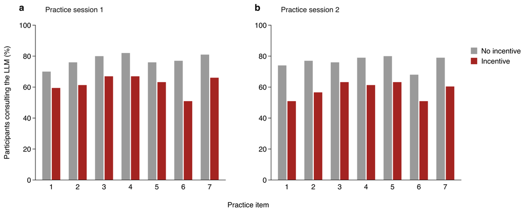

Participants consulting the LLM on each practice item, by incentive condition and session. Red: incentive; grey: no incentive. The primary sample includes participants with zero LLM use.

```r
ai_item_consultation_plot <- ggplot(ai_item_consultation, aes(item_position, percent, fill = condition)) +
  geom_col(position = position_dodge(width = .72), width = .64) +
  facet_wrap(~ session, nrow = 1, axes = 'all_y') +
  scale_fill_manual(values = c('No incentive' = '#AAAAAA', 'Incentive' = '#B5362B'),
                    breaks = c('No incentive', 'Incentive')) +
  scale_y_continuous(limits = c(0, 100), breaks = seq(0, 100, 20),
                     expand = expansion(mult = c(0, 0))) +
  labs(x = 'Practice item', y = 'Participants consulting the LLM (%)', fill = NULL) +
  theme_classic(base_size = 7, base_family = figure_font) +
  theme(text = element_text(size = 7, color = 'black'),
        axis.text = element_text(size = 7, color = 'black'),
        axis.title = element_text(size = 7),
        axis.line = element_line(linewidth = .2, color = 'black'),
        axis.ticks = element_line(linewidth = .2, color = 'black'),
        axis.ticks.x = element_blank(),
        axis.ticks.length = grid::unit(1, 'mm'),
        axis.text.x = element_text(margin = margin(t = 4)),
        strip.background = element_blank(),
        strip.text = element_text(face = 'plain', size = 7, hjust = .075,
                                  margin = margin(t = 2, b = 12)),
        axis.title.x = element_text(margin = margin(t = 11)),
        axis.title.y = element_text(margin = margin(r = 8)),
        legend.position = 'right',
        legend.justification = c(0, .84),
        legend.text = element_text(size = 7),
        legend.key.size = grid::unit(2.5, 'mm'),
        legend.key.spacing.y = grid::unit(1, 'mm'),
        legend.margin = margin(0, 0, 0, 2),
        panel.spacing = grid::unit(10, 'mm'),
        plot.margin = margin(4, 4, 4, 4))

# Place panel letters beside the session titles, outside the plotting areas.
ai_item_consultation_plot <- ggplotGrob(ai_item_consultation_plot)
ai_strip_layout <- ai_item_consultation_plot$layout[
  grepl('^strip-t', ai_item_consultation_plot$layout$name), ]
ai_strip_layout <- ai_strip_layout[order(ai_strip_layout$l), ]
for (i in seq_len(nrow(ai_strip_layout))) {
  ai_item_consultation_plot <- gtable::gtable_add_grob(
    ai_item_consultation_plot,
    grid::textGrob(letters[i], x = 0, y = 1, just = c('left', 'top'),
                   gp = grid::gpar(fontfamily = figure_font, fontface = 'bold', fontsize = 9)),
    t = ai_strip_layout$t[i], l = ai_strip_layout$l[i] - 1,
    clip = 'off', name = paste0('panel-letter-', i)
  )
}
grid::grid.newpage()
grid::grid.draw(ai_item_consultation_plot)
```

```r
ggsave(
  file.path(figure_dir, "ai_items_consulted.png"),
  plot = ai_item_consultation_plot,
  width = 180, height = 73, units = "mm",
  dpi = 600, bg = "white"
)
ggsave(
  file.path(figure_dir, "ai_items_consulted.pdf"),
  plot = ai_item_consultation_plot,
  width = 180, height = 73, units = "mm",
  device = grDevices::cairo_pdf, bg = "white"
)
```

# 4 Changes in unaided performance without LLM assistance

Among participants without incentives, a mixed model estimates performance by assessment, LLM assignment, and their interaction, with a random intercept for each participant.

```r
trajectory_participants <- participants %>%
  filter(incentive == 0) %>%
  transmute(
    participant_id,
    ai_group = factor(
      ai,
      levels = c(0, 1),
      labels = c("Control", "LLM")
    ),
    Baseline = bl_score_proportion,
    Immediate = test_score_proportion,
    Delayed = del_score_proportion
  )

trajectory_long <- trajectory_participants %>%
  pivot_longer(
    cols = c(Baseline, Immediate, Delayed),
    names_to = "time",
    values_to = "score"
  ) %>%
  filter(!is.na(score)) %>%
  mutate(time = factor(time, levels = c("Baseline", "Immediate", "Delayed")))

trajectory_model <- lme4::lmer(
  score ~ time * ai_group + (1 | participant_id),
  data = trajectory_long,
  REML = TRUE
)
```

Control-group learning gains compare immediate and delayed performance with baseline, with 95% confidence intervals.

```r
no_ai_means <- emmeans(
  trajectory_model, ~ time | ai_group, lmer.df = "satterthwaite"
)
no_ai_gains <- as.data.frame(summary(contrast(
  no_ai_means, method = list(
    "Immediate - Baseline" = c(-1, 1, 0),
    "Delayed - Baseline" = c(-1, 0, 1)
  ), adjust = "none"
), infer = c(TRUE, FALSE))) %>%
  filter(ai_group == "Control")
knitr::kable(no_ai_gains %>% transmute(
    Comparison = contrast,
    `Gain (pp)` = sprintf("%.2f", 100 * estimate),
    `95% CI (pp)` = sprintf("[%.2f, %.2f]", 100 * lower.CL, 100 * upper.CL)
  ))
```

| Comparison | Gain (pp) | 95% CI (pp) |
| --- | --- | --- |
| Immediate - Baseline | 20.60 | [16.20, 25.00] |
| Delayed - Baseline | 18.18 | [13.54, 22.83] |

**Full output and unformatted results**

```r
print(summary(trajectory_model), correlation = TRUE, digits = 17)
```

```
## Linear mixed model fit by REML ['lmerMod']
## Formula: score ~ time * ai_group + (1 | participant_id)
##    Data: trajectory_long
##
## REML criterion at convergence: -73.2
##
## Scaled residuals:
##                    Min                     1Q                 Median
## -2.7631516903587702849 -0.5612617406313678003 -0.0044477192633201618
##                     3Q                    Max
##  0.5517933286290098716  2.8279308568053669326
##
## Random effects:
##  Groups         Name        Variance             Std.Dev.
##  participant_id (Intercept) 0.050877055888481335 0.22555942872884152
##  Residual                   0.025082506577608764 0.15837457680325073
## Number of obs: 570, groups:  participant_id, 200
##
## Fixed effects:
##                                        Estimate            Std. Error
## (Intercept)                0.438999999999988788  0.027560762410733311
## timeImmediate              0.206000000000005457  0.022397547445025701
## timeDelayed                0.181844865461674776  0.023640236017830472
## ai_groupLLM                0.036000000000008137  0.038976803990601820
## timeImmediate:ai_groupLLM -0.091000000000005563  0.031674915360650230
## timeDelayed:ai_groupLLM   -0.050121757970920867  0.033577540358093384
##                                        t value
## (Intercept)               15.92844000000000015
## timeImmediate              9.19744000000000028
## timeDelayed                7.69217999999999957
## ai_groupLLM                0.92362999999999995
## timeImmediate:ai_groupLLM -2.87293999999999983
## timeDelayed:ai_groupLLM   -1.49272000000000005
##
## Correlation of Fixed Effects:
##             (Intr) tmImmd tmDlyd a_gLLM tI:_LL
## timeImmedit -0.406
## timeDelayed -0.385  0.474
## ai_groupLLM -0.707  0.287  0.272
## tmImmd:_LLM  0.287 -0.707 -0.335 -0.406
## tmDlyd:_LLM  0.271 -0.334 -0.704 -0.383  0.472
```

```r
print(as.data.frame(no_ai_means), digits = 17, row.names = FALSE)
```

```
## ai_group = Control:
##  time         emmean         SE     df  lower.CL  upper.CL
##  Baseline  0.4390000 0.02756076 307.13 0.3847682 0.4932318
##  Immediate 0.6450000 0.02756076 307.13 0.5907682 0.6992318
##  Delayed   0.6208449 0.02857982 340.98 0.5646299 0.6770598
##
## ai_group = LLM:
##  time         emmean         SE     df  lower.CL  upper.CL
##  Baseline  0.4750000 0.02756076 307.13 0.4207682 0.5292318
##  Immediate 0.5900000 0.02756076 307.13 0.5357682 0.6442318
##  Delayed   0.6067231 0.02874954 346.53 0.5501776 0.6632687
##
## Degrees-of-freedom method: satterthwaite
## Confidence level used: 0.95
```

```r
print(as.data.frame(no_ai_gains), digits = 17, row.names = FALSE)
```

```
##              contrast ai_group            estimate                   SE
##  Immediate - Baseline  Control 0.20600000000000546 0.022397547445025701
##    Delayed - Baseline  Control 0.18184486546167478 0.023640236017830472
##                  df            lower.CL            upper.CL
##  366.09722692278183 0.16195600709006391 0.25004399290994700
##  371.10464599114641 0.13535924935838886 0.22833048156496069
```

The figure uses model-estimated control-group means and gains, expressed as percentages and percentage-point differences, respectively.

```r
control_learning_counts <- trajectory_long %>%
  filter(ai_group == "Control") %>%
  count(time, name = "n_observed")
control_learning_means <- as.data.frame(confint(
  no_ai_means, level = .95, adjust = "none"
)) %>%
  filter(ai_group == "Control") %>%
  transmute(
    time, performance_percent = 100 * emmean,
    CI_low_percent = 100 * lower.CL, CI_high_percent = 100 * upper.CL
  )
control_learning_gains <- no_ai_gains %>%
  transmute(
    assessment = factor(sub(" - Baseline", "", contrast, fixed = TRUE),
                        levels = c("Delayed", "Immediate")),
    gain_pp = 100 * estimate,
    CI_low_pp = 100 * lower.CL, CI_high_pp = 100 * upper.CL,
    gain_label = sprintf("%+.2f pp", gain_pp)
  )
control_learning_n_labels <- setNames(
  sprintf("%s\n(n = %d)", control_learning_counts$time,
          control_learning_counts$n_observed),
  as.character(control_learning_counts$time)
)
```

Supplementary Fig. 3 shows the control-group performance trajectory and gains from baseline.

```r
control_learning_colours <- c(
  Baseline = "#9AA8AD", Immediate = "#264653", Delayed = "#C46F6F"
)
control_learning_theme <- theme_classic(base_size = 7, base_family = figure_font) +
  theme(
    axis.text = element_text(size = 7, colour = "black"),
    axis.line = element_line(linewidth = .25),
    axis.ticks = element_line(linewidth = .25),
    axis.ticks.length = grid::unit(1, "mm"),
    plot.tag = element_text(size = 9, face = "bold"),
    plot.tag.position = "topleft",
    plot.title = element_text(size = 7, face = "bold", hjust = 0),
    plot.margin = margin(5, 6, 4, 5),
    legend.position = "none"
  )
control_learning_trajectory_panel <- ggplot() +
  geom_line(
    data = control_learning_means,
    aes(time, performance_percent, group = 1), linewidth = .3, colour = "black"
  ) +
  geom_errorbar(
    data = control_learning_means,
    aes(time, ymin = CI_low_percent, ymax = CI_high_percent, colour = time),
    width = .1, linewidth = .4
  ) +
  geom_point(
    data = control_learning_means,
    aes(time, performance_percent, colour = time), size = 1.8
  ) +
  scale_colour_manual(values = control_learning_colours) +
  scale_x_discrete(labels = control_learning_n_labels) +
  scale_y_continuous(breaks = seq(40, 80, 10), expand = expansion(mult = .02)) +
  coord_cartesian(ylim = c(0, 100)) +
  labs(x = "Assessment", y = "Unaided performance (% correct)",
       title = "Control, no incentive", tag = "a") +
  control_learning_theme
control_learning_gain_panel <- ggplot(
  control_learning_gains, aes(gain_pp, assessment)
) +
  geom_vline(xintercept = 0, linetype = "dashed", linewidth = .3, colour = "grey50") +
  geom_segment(
    aes(x = CI_low_pp, xend = CI_high_pp, yend = assessment, colour = assessment), linewidth = .5
  ) +
  geom_point(aes(colour = assessment), size = 1.8) +
  geom_text(aes(label = gain_label), nudge_y = .19, family = figure_font, size = 7 / ggplot2::.pt) +
  scale_colour_manual(values = control_learning_colours) +
  scale_x_continuous(expand = expansion(mult = c(.05, .12))) +
  expand_limits(x = 0) +
  scale_y_discrete(expand = expansion(add = .65)) +
  labs(x = "Gain over baseline (percentage points)", y = NULL,
       title = "Learning gains", tag = "b") +
  control_learning_theme

control_learning_figure <- patchwork::wrap_plots(
  control_learning_trajectory_panel, control_learning_gain_panel,
  nrow = 1, widths = c(.53, .47)
)
print(control_learning_figure)
```

[figure not shown]

```r
ggsave(
  file.path(figure_dir, "control_learning_trajectory.pdf"),
  plot = control_learning_figure, width = 180, height = 85, units = "mm",
  device = grDevices::cairo_pdf, bg = "white"
)
ggsave(
  file.path(figure_dir, "control_learning_trajectory.png"),
  plot = control_learning_figure, width = 180, height = 85, units = "mm",
  dpi = 600, bg = "white"
)
```

# 5 Participant flow

The flow table applies exclusions cumulatively. Session counts and retention rates use assigned participants with baseline data who did not withdraw consent or decline data use. Completion means a score is available; Pearson chi-square tests compare retention across the four conditions.

```r
flow_steps <- list(
  "Recruited and approved on Prolific" = participants_all$recruitment_status == "APPROVED",
  "Consent retained" = !participants_all$consent_withdrawn,
  "Honesty check approved" = !participants_all$declined_data_use,
  "Passed attention check" = participants_all$attention_check_passed,
  "Baseline data available" = participants_all$has_baseline,
  "Continued beyond baseline" = participants_all$assigned,
  "Completed Training 1" = participants_all$has_training_1,
  "Completed Training 2" = participants_all$has_training_2,
  "Completed immediate test: primary sample" = participants_all$has_immediate_test,
  "Completed delayed test" = participants_all$has_delayed_test
)
flow_kept <- Reduce(`&`, flow_steps, accumulate = TRUE)
sample_flow <- data.frame(
  Step = names(flow_steps),
  Remaining = vapply(flow_kept, sum, integer(1))
) %>%
  mutate(Removed = lag(Remaining) - Remaining) %>%
  select(Step, Removed, Remaining)

retention_counts <- participants_all %>%
  filter(included_retention) %>%
  group_by(group_condition, condition_label) %>%
  summarise(n_assigned = n(), n_training_1 = sum(has_training_1),
            n_training_2 = sum(has_training_2), n_immediate = sum(has_immediate_test),
            n_delayed = sum(has_delayed_test), .groups = "drop") %>%
  arrange(condition_label)
knitr::kable(sample_flow, caption = "Cumulative participant flow")
```

Cumulative participant flow

| Step | Removed | Remaining |
| --- | --- | --- |
| Recruited and approved on Prolific | NA | 520 |
| Consent retained | 2 | 518 |
| Honesty check approved | 8 | 510 |
| Passed attention check | 1 | 509 |
| Baseline data available | 0 | 509 |
| Continued beyond baseline | 57 | 452 |
| Completed Training 1 | 9 | 443 |
| Completed Training 2 | 34 | 409 |
| Completed immediate test: primary sample | 1 | 408 |
| Completed delayed test | 54 | 354 |

```r
session_flow <- retention_counts %>%
  transmute(Condition = as.character(condition_label),
    `Continued beyond baseline (n)` = n_assigned, `Training 1 completed (n)` = n_training_1,
    `Training 2 completed (n)` = n_training_2, `Immediate completed (n)` = n_immediate,
    `Delayed completed (n)` = n_delayed)
session_flow <- bind_rows(session_flow,
  data.frame(Condition = "Pooled", as.list(colSums(session_flow[-1])), check.names = FALSE))
knitr::kable(session_flow, caption = "Session completion by condition")
```

Session completion by condition

| Condition | Continued beyond baseline (n) | Training 1 completed (n) | Training 2 completed (n) | Immediate completed (n) | Delayed completed (n) |
| --- | --- | --- | --- | --- | --- |
| Control (no incentive) | 113 | 111 | 100 | 100 | 86 |
| Control + incentive | 114 | 109 | 103 | 102 | 89 |
| LLM (no incentive) | 113 | 113 | 100 | 100 | 84 |
| LLM + incentive | 112 | 110 | 106 | 106 | 95 |
| Pooled | 452 | 443 | 409 | 408 | 354 |

```r
retention_transitions <- list(
  "Training 1 to immediate" = c("n_training_1", "n_immediate"),
  "Training 1 to delayed" = c("n_training_1", "n_delayed"),
  "Immediate to delayed" = c("n_immediate", "n_delayed")
)
retention_by_condition <- bind_rows(lapply(names(retention_transitions), function(label) {
  columns <- retention_transitions[[label]]
  data.frame(
    Condition = as.character(retention_counts$condition_label), Transition = label,
    Eligible = retention_counts[[columns[1]]], Completed = retention_counts[[columns[2]]],
    `Retention (%)` = 100 * retention_counts[[columns[2]]] / retention_counts[[columns[1]]],
    check.names = FALSE
  )
}))
pooled_retention <- retention_by_condition %>%
  group_by(Transition) %>%
  summarise(Condition = "Pooled", Eligible = sum(Eligible), Completed = sum(Completed),
            `Retention (%)` = 100 * Completed / Eligible, .groups = "drop") %>%
  arrange(match(Transition, names(retention_transitions))) %>%
  select(Condition, Transition, Eligible, Completed, `Retention (%)`)
knitr::kable(bind_rows(pooled_retention, retention_by_condition), digits = 1,
             caption = "Retention between assessments")
```

Retention between assessments

| Condition | Transition | Eligible | Completed | Retention (%) |
| --- | --- | --- | --- | --- |
| Pooled | Training 1 to immediate | 443 | 408 | 92.1 |
| Pooled | Training 1 to delayed | 443 | 354 | 79.9 |
| Pooled | Immediate to delayed | 408 | 354 | 86.8 |
| Control (no incentive) | Training 1 to immediate | 111 | 100 | 90.1 |
| Control + incentive | Training 1 to immediate | 109 | 102 | 93.6 |
| LLM (no incentive) | Training 1 to immediate | 113 | 100 | 88.5 |
| LLM + incentive | Training 1 to immediate | 110 | 106 | 96.4 |
| Control (no incentive) | Training 1 to delayed | 111 | 86 | 77.5 |
| Control + incentive | Training 1 to delayed | 109 | 89 | 81.7 |
| LLM (no incentive) | Training 1 to delayed | 113 | 84 | 74.3 |
| LLM + incentive | Training 1 to delayed | 110 | 95 | 86.4 |
| Control (no incentive) | Immediate to delayed | 100 | 86 | 86.0 |
| Control + incentive | Immediate to delayed | 102 | 89 | 87.3 |
| LLM (no incentive) | Immediate to delayed | 100 | 84 | 84.0 |
| LLM + incentive | Immediate to delayed | 106 | 95 | 89.6 |

```r
retention_tests <- bind_rows(lapply(names(retention_transitions), function(label) {
  counts <- filter(retention_by_condition, Transition == label)
  result <- chisq.test(cbind(Not_completed = counts$Eligible - counts$Completed,
                            Completed = counts$Completed), correct = FALSE)
  data.frame(Transition = label, Eligible = sum(counts$Eligible),
             `Chi-square` = unname(result$statistic), df = unname(result$parameter),
             p = fmt_p(result$p.value), check.names = FALSE)
}))
knitr::kable(retention_tests, digits = 2,
             caption = "Pearson chi-square tests of retention by condition")
```

Pearson chi-square tests of retention by condition

| Transition | Eligible | Chi-square | df | p |
| --- | --- | --- | --- | --- |
| Training 1 to immediate | 443 | 5.71 | 3 | 0.127 |
| Training 1 to delayed | 443 | 5.66 | 3 | 0.130 |
| Immediate to delayed | 408 | 1.49 | 3 | 0.684 |

# 6 Correlation between baseline and subsequent unaided performance

Baseline–test correlations are calculated after removing condition means. Approximate 95% Fisher-z confidence intervals account for the three condition contrasts; the sample-size planning assumption is rho = .60.

```r
baseline_correlation <- function(dat, outcome) {
  dat <- dat[complete.cases(dat[, c("bl_score_proportion", outcome,
                                  "group_condition")]), ]
  x <- dat$bl_score_proportion
  y <- dat[[outcome]]
  n <- nrow(dat)
  condition_design <- model.matrix(~ factor(group_condition), data = dat)
  k <- qr(condition_design)$rank - 1L
  x <- lm.fit(condition_design, x)$residuals
  y <- lm.fit(condition_design, y)$residuals
  r <- cor(x, y)
  ci <- tanh(atanh(r) + c(-1, 1) * qnorm(.975) / sqrt(n - k - 3))
  data.frame(Outcome = outcome, N = n,
             r = r, CI_lower = ci[1], CI_upper = ci[2])
}

baseline_correlation_results <- bind_rows(lapply(
  c("test_score_proportion", "del_score_proportion"), function(outcome) {
    baseline_correlation(participants, outcome)
  }
))
appendix_baseline_correlations <- baseline_correlation_results %>%
  transmute(
    Assessment = ifelse(Outcome == "test_score_proportion", "Immediate", "Delayed"),
    N, r, `95% CI` = sprintf("[%.2f, %.2f]", CI_lower, CI_upper)
  )
knitr::kable(appendix_baseline_correlations, digits = 2)
```

| Assessment | N | r | 95% CI |
| --- | --- | --- | --- |
| Immediate | 408 | 0.68 | [0.62, 0.73] |
| Delayed | 354 | 0.67 | [0.60, 0.72] |

```r
cat("Sample-size planning assumption: rho = .60.\n")
```

```
## Sample-size planning assumption: rho = .60.
```

**Full output and unformatted results**

```r
print(as.data.frame(baseline_correlation_results), digits = 17, row.names = FALSE)
```

```
##                Outcome   N                   r            CI_lower
##  test_score_proportion 408 0.67635277582807107 0.61975469193431321
##   del_score_proportion 354 0.66512587977726534 0.60238719296041410
##             CI_upper
##  0.72595178405028926
##  0.71969682341694785
```